# Is it necessary to apply chemical weed control in short-rotation poplar plantations on deep soil sites? - ScienceDirect

[figure not shown]

[figure not shown]

## [Industrial Crops and Products](https://www.sciencedirect.com/journal/industrial-crops-and-products)

[Volume 184](https://www.sciencedirect.com/journal/industrial-crops-and-products/vol/184/suppl/C), 15 September 2022, 115025

# Is it necessary to apply chemical weed control in short-rotation poplar plantations on deep soil sites?

[JingyiFu<sup>a</sup><sup>1</sup>](https://www.sciencedirect.com/science/article/abs/pii/S0926669022005088#!)[SongyanZou<sup>a</sup><sup>1</sup>](https://www.sciencedirect.com/science/article/abs/pii/S0926669022005088#!)[MarkColeman<sup>b</sup>](https://www.sciencedirect.com/science/article/abs/pii/S0926669022005088#!)[XimengLi<sup>c</sup>](https://www.sciencedirect.com/science/article/abs/pii/S0926669022005088#!)[WeiHu<sup>d</sup>](https://www.sciencedirect.com/science/article/abs/pii/S0926669022005088#!)[AoyuWang<sup>a</sup>](https://www.sciencedirect.com/science/article/abs/pii/S0926669022005088#!)[PeiZhang<sup>a</sup>](https://www.sciencedirect.com/science/article/abs/pii/S0926669022005088#!)[ZihangZeng<sup>e</sup>](https://www.sciencedirect.com/science/article/abs/pii/S0926669022005088#!)[ChangjunDing<sup>f</sup>](https://www.sciencedirect.com/science/article/abs/pii/S0926669022005088#!)[BenyeXi<sup>a</sup>](https://www.sciencedirect.com/science/article/abs/pii/S0926669022005088#!)[NanDi<sup>g</sup>](https://www.sciencedirect.com/science/article/abs/pii/S0926669022005088#!)

https://doi.org/10.1016/j.indcrop.2022.115025[Get rights and content](https://s100.copyright.com/AppDispatchServlet?publisherName=ELS&contentID=S0926669022005088&orderBeanReset=true)

## Abstract

[Chemical weed control](https://www.sciencedirect.com/topics/agricultural-and-biological-sciences/chemical-weed-control) has been widely applied in [plantation forests](https://www.sciencedirect.com/topics/agricultural-and-biological-sciences/forest-plantations) around the world. However, understanding the long-term influence of weed control on stand growth and its underlying mechanisms is still limited. We conducted a six-year (2016–2021; an entire rotation) weed control study in Chinese [white poplar](https://www.sciencedirect.com/topics/agricultural-and-biological-sciences/populus-alba) ([Populus tomentosa](https://www.sciencedirect.com/topics/agricultural-and-biological-sciences/populus-tomentosa) Carr.) plantations established using tall planting stock on a deep soil site, which is a typical afforestation mode for poplars in north China. Three treatments of chemical weed control degree were implemented: no weeding (W<sub>0</sub>), removing weeds within 50 cm distance from the tree row (W<sub>50</sub>) and removing all weeds on the ground (W<sub>150</sub>). Different tree growth indicators, soil water content (*θ*), tree root distribution, and [soil physical properties](https://www.sciencedirect.com/topics/agricultural-and-biological-sciences/soil-physical-properties) were measured. There was no weed control degree effect on *θ* in 2017 (*P* = 0.4408) but significant *θ* difference (*P* = 0.0140) among treatments existed in 0–30 cm soil in 2021. Different degrees of weed control did not change [soil physical properties](https://www.sciencedirect.com/topics/agricultural-and-biological-sciences/soil-physical-properties) (*P* > 0.05) after the long-term application of chemical weeding. There were no differences (*P* > 0.05) in all growth indicators. But the cumulative increments of tree diameter, height, stand volume index, and biomass at the end of the rotation in W<sub>150</sub> were numerically 2–27% lower than W<sub>0</sub> and 11–26% lower than W<sub>50</sub>. The total fine roots biomass increased with decreasing weed control degree, although the difference was non-significant (*P* > 0.05). The fine root distribution pattern indicated that there might be many fine roots below 200 cm depth. The tree growth response to weed control may be attributed to tall planting stock that avoids light competition from weeds and deep soil resource exploration by tree roots that alleviate competition by shallow weed roots. Consequently, it may be unnecessary to apply chemical weed control in poplar plantations established using tall planting stock on deep soil sites. Our findings provide guidance for the sustainable management of industrial [plantation forests](https://www.sciencedirect.com/topics/agricultural-and-biological-sciences/forest-plantations).

## Graphical Abstract

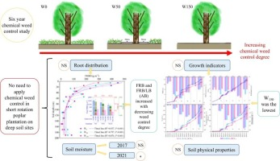

## Introduction

Given the prospect of drastic global climate change and continued deterioration of the ecological environment, plantation forests are playing an increased role in regulating climate, conserving water and soil, and maintaining atmospheric carbon, oxygen, and energy balance (Hartley, 2002; FAO, 2018; Zeng et al., 2021). Plantation forests account for an increasing proportion of commercial timber production worldwide so that they are playing a critical role in maintaining the wood supply (FAO, 2016b). Therefore, developing plantation forests, especially the fast-growing and high-yielding plantations, will be crucial to ecological restoration and the maintenance of economic benefits (Liu et al., 2022).

The improvement of plantation growth depends on reasonable and efficient intensive cultivation techniques (Dickmann, 2006, Albaugh et al., 2016, Xi et al., 2021). These techniques will also support long-term site productivity and improvement of wood quality. As a vital cultivation technique, weed control is critical to establishing plantation forests successfully and can affect other forest management decisions (Hansen et al., 1984, Wagner et al., 2006, Deng et al., 2020). During the management of plantations, weed control may last for one or a few years, so its high-frequency and long-term interference with the understory vegetation may subsequently influence the performance of trees (Deng et al., 2020, Zhou et al., 2021). Many studies fully demonstrate the adverse effects of weeds on plantation performance (Wagner et al., 1989, Wagner et al., 2006, Rey Benayas et al., 2005, Deng et al., 2020). For example, weeds can have strong negative effects on the growth and physiology of trees and even threaten survival through interspecific competition for growth resources such as nutrients, light, and water (Kabba et al., 2011, Rey Benayas et al., 2005, Coll et al., 2007, Henkel-Johnson et al., 2016). In addition, weeds may also inhibit tree growth by releasing allelopathic chemicals (Qin et al., 2018, Scavo and Mauromicale, 2021). Therefore, scientific weed control can improve the growth, resistance, and resilience of forest plantations by increasing site growth resources available for tree crops and influencing soil quality and stand ecological stability (Coll et al., 2007, Zhao et al., 2008, Stanturf and Oosten, 2014).

Weed control of plantation forests has long been investigated due to its critical role in determining the success of afforestation and in influencing plantation performance. In different regions worldwide, weed control studies are mainly conducted for the primary afforestation tree species that bring great economic or/and ecological benefits, such as *Eucalyptus*, *Populus*, *Pinus*, *Quercus*, *Picea*, etc. Although most studies find that controlling weeds promotes plantation growth (Nilsson and Örlander, 1999, Garau et al., 2009, Wagner et al., 2006, Deng et al., 2020), the review of Wagner et al. (2006) showed that the growth promotion degree of weed control exhibited a considerable range of variation (4–11800%) and some studies found that weed control does not influence or even reduces tree growth or yield (Hansen and Netzer, 1985, Sage, 1999, Zhao et al., 2008, Abraham and Joseph, 2016). The large difference in these findings can be mainly attributed to that the effect of weeding on tree growth can be greatly conditioned by many biological and abiotic factors. These factors include site condition, tree species, region, and weeding method, among other factors. Therefore, it is still necessary to investigate the actual effects of weed control on the performance of regional plantation types to derive optimal weed control strategies for them.

The duration of weed control is a key parameter in weeding scheduling, and it has been often suggested that effective weed control should last until canopy closure when the shade of the tree canopy can prevent the growth of weeds (Buhler et al., 1998, Wagner et al., 2006, Morhart et al., 2013). Therefore, most of the published weed control studies only investigated the response of tree growth to weed control during establishment (Wagner et al., 2006). However, a deep understanding of weed control effects on plantation productivity and accurately determining the optimal weed control duration require knowing long-term tree growth response, which is poorly understood at present. Thus, it is crucial to measure the variation of tree growth response over a significant portion of the forest rotation or the entire rotation (Wagner et al., 2006, Henkel-Johnson et al., 2016). Unfortunately, such a study is still limited, and most of the relevant research was mainly conducted on needle-leaf tree species (Wagner et al., 2006).

Another important parameter of weed control management is the degree of weed control, i.e., what proportion of the land area in a stand should be weeded (Woods et al., 1992, Garau et al., 2009). Many studies have been conducted to solve this question for different tree species, but answers are inconclusive. In some cases, complete weed control throughout the stand can cause greater benefits than weed control only along the tree row (Tubby and Amstrong, 2002; Morhart et al., 2013). Whereas, in other cases, strip weed control was more advantageous (Woods et al., 1992, Coll et al., 2007, Abraham and Joseph, 2016). These divergent findings indicate that it is difficult to extrapolate the conclusion on weed control degree from one site to another. Thus, it is imperative to assess the impact of weed control degree on stand performance to derive the optimal weed control strategy for the typical combinations of afforestation sites and afforestation tree species in a region. However, the current understanding of this impact is still limited. This limitation mainly focuses on the relationship between weed control degree (or weed cover level) and tree growth (Wagner et al., 1989; Wagner et al., 2006; Desrochers and Sigouin, 2014; Henkel-Johnson et al., 2016). The influences of weed control degree on fine roots distribution and soil physical properties have rarely been investigated. Such information can be crucial to elucidate the influence mechanism that weed control has on plantation growth.

Poplar is one of the most essential fast-growing and high-yielding tree species in the middle latitudes of the world (FAO, 2016a; Xi et al., 2021). Poplar plantations have reached 7.57 million ha in China, ranking second in the world, and they produce nearly 30% of domestic timber (FAO, 2016a; NFGA, 2019). So, poplar is playing a pivotal role in maintaining Chinese wood resource supply and ecological security (Zheng, 2006, Fang, 2008; NFGA, 2019; Xi et al., 2021). Fast growth and high resource-demand of poplar results in strong responses to external factors. Therefore, maintaining and improving poplar plantation productivity requires more frequent intervention than plantations of slow-growing tree species. At present, due to the low average productivity of poplar plantations in China (Xi et al., 2021), it is essential to innovate intensive poplar cultivation techniques in China, including weed control. In the past decades, many efforts have been made to address high-efficiency weed control in poplar plantations in China (Hou et al., 2006, Yu, 2017, Pang, 2018). Many formulated Chinese industry and local standards for poplar cultivation include recommendations on weed control. However, through a thorough review of 36 such standards, we found that less than half (47%) of these standards recommend detailed weed control scheduling. And the recommended weed control method, weeding times per year, and the duration for controlling weeds also vary greatly. Besides, most standards give no specific suggestions on weed control degree. These uncertainties will inevitably hinder the widespread, rational, and efficient application of weed control in poplar plantations. Therefore, to solve these uncertainties, it is urgent to conduct systematic studies on the effect of weed control on the performance of poplar plantations under typical cultivation modes in China, especially considering the increasingly important role of poplar plantations in alleviating the wood safety crisis and protecting the ecological environment.

To improve poplar plantation productivity in China and explore the efficiency of long-term chemical weed control, we conducted a six-year (whole rotation) chemical weed control study in a plantation of *Populus tomentosa* Carr. (Chinese white poplar). *P. tomentosa* is endemic to China and originated from the natural hybridization between *P. adenopoda* or *P. davidiana* (female parents) and *P. alba* (male parent) (Wang et al., 2019). This species has been widely planted in north China for developing industrial raw material plantations. The study plantation was established with tall planting stock on a deep soil site, a typical and popular afforestation mode for poplars in north China. However, most of the existing weed control studies in poplar plantations established using short cuttings can only provide limited technical reference for weed control under such an afforestation mode (Hansen et al., 1984, Kabba et al., 2011, Henkel-Johnson et al., 2016). Herbicide was chosen to control weeds in this study because chemical control of weeds is prevailing worldwide due to its high weed control efficiency and relatively low cost compared to other weed control methods (Coll et al., 2007, Morhart et al., 2013).

The objectives of this study were (1) to explore the long-term influences of different chemical weed control degrees on stand growth, (2) to investigate the weed control effects on soil moisture and soil physical properties, and (3) to evaluate whether different weed control degrees would exert an influence on the fine root distribution. Based on the achievement of these objectives, we tested two hypothesizes: (1) increasing weed control could significantly promote the growth of poplar plantations; and (2) the underlying mechanisms were that weed control would increase the availability of water and light to trees through influencing soil water condition, soil physical properties, fine root distribution, and leaf area index.

## CRediT authorship contribution statement

Jingyi Fu, Songyan Zou and Benye Xi: Designed the research; Songyan Zou, Jingyi Fu, Pei Zhang and Aoyu Wang: Performed the research; Jingyi Fu, Mark Coleman and Benye Xi: Analysed data; Jingyi Fu and Benye Xi: Wrote the paper; Jingyi Fu, Songyan Zou, Mark Coleman, Ximeng Li, Wei Hu, Aoyu Wang, Pei Zhang, Zihang Zeng, Changjun Ding, Benye Xi and Nan Di: Made the manuscript revisions.

## Declaration of Competing Interest

The authors declare that they have no known competing financial interests or personal relationships that could have appeared to influence the work reported in this paper.

## Acknowledgments

This research was supported by the National Key Research and Development Program of China (Grant No. 2021YFD2201203).

## References (81)

- D.H. Zhao *et al.*

### Pine growth response to different site-preparation methods with or without post-plant herbaceous weed control on North Florida’s Lower Coastal Plain

### Ecol. Manag.

  (2008)
- B.Y. Xi *et al.*

### Irrigation management in poplar (*Populus* spp.) plantations: a review

### Ecol. Manag.

  (2021)
- B.Y. Xi *et al.*

### Characteristics of fine root system and water uptake in a triploid *Populus tomentosa* plantation in the North China Plain: implications for irrigation water management

### Agric. Water Manag.

  (2013)
- P.V. Woods *et al.*

### Effect of annual weeds on water and nitrogen availability to *Pinus radiata* trees in a young plantation

### Ecol. Manag.

  (1992)
- H. Sixto *et al.*

### Assessment of the effect of broad-spectrum pre-emergence herbicides in poplar nurseries

### Crop Prot.

  (2001)
- J.M. Rey Benayas *et al.*

### Effects of artificial shading and weed mowing in reforestation of Mediterranean abandoned cropland with contrasting *Quercus* species

### Ecol. Manag.

  (2005)
- E. Rabot *et al.*

### Soil structure as an indicator of soil functions: a review

### Geoderma

  (2018)
- F.C. Qin *et al.*

### Effects of allelopathy and competition for water and nutrients on survival and growth of tree species in *Eucalyptus urophylla* plantations

### . Ecol. Manag.

  (2018)
- D.D. Li *et al.*

### Understanding the relationship between biomass production and water use of *Populus tomentosa* trees throughout an entire short-rotation

### Agric. Water Manag.

  (2021)
- D.D. Li *et al.*

### Tree growth patterns and diagnosis of water status based on trunk diameter fluctuations in fast-growing *Populus tomentosa* plantations

### Agric. Water Manag.

  (2020)

**<sup>1</sup>**

These authors contributed equally to this work.

© 2022 Elsevier B.V. All rights reserved.

[figure not shown]